# Сетевые технологии

Лабораторная работа №3

Элсаиед Адел

Российский университет дружбы народов, Москва, Россия

19 января 2026

# Цель и задачи работы

## Цель лабораторной работы

Изучение кадров Ethernet и анализ PDU протоколов транспортного и прикладного уровней стека TCP/IP с использованием Wireshark.

# Ход выполнения работы

## Вывод параметров подключения (ipconfig /all)

- Определены параметры интерфейса Wi-Fi
- Зафиксированы DHCP/DNS и срок аренды
- Получены IPv4/IPv6 адреса, маска, шлюз по умолчанию

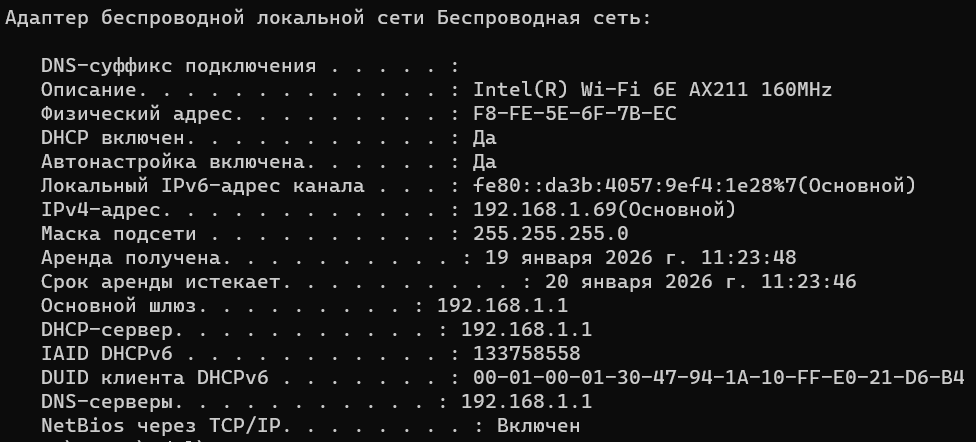

ipconfig /all

## Основные параметры сети

- IPv4-адрес: `192.168.1.69`
- Маска: `255.255.255.0`
- Шлюз по умолчанию: `192.168.1.1`
- DNS/DHCP: `192.168.1.1`
- MAC (Wi-Fi): `F8-FE-5E-6F-7B-EC`

## Проверка доступности шлюза (ping)

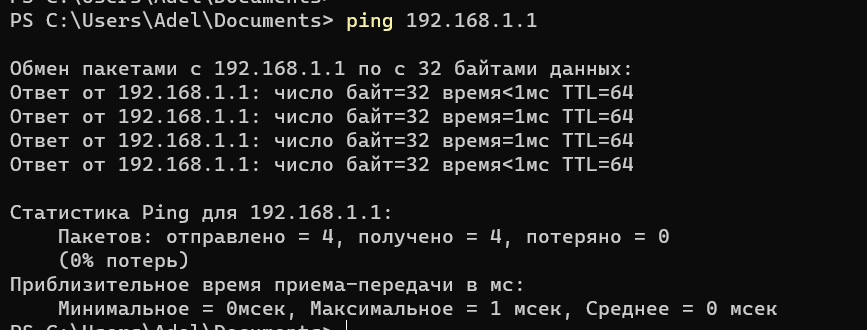

ping 192.168.1.1

## Структура MAC-адреса

Пример: `F8-FE-5E-6F-7B-EC` - OUI (производитель): `F8-FE-5E` (первые 24 бита) - NIC (интерфейс): `6F-7B-EC` (последние 24 бита)

Определение типа по первому октету `F8` = `11111000`: - I/G (bit0) = 0 → **unicast** - U/L (bit1) = 0 → **globally administered**

## Фильтрация трафика и ICMP Echo Request

- ICMP Echo Request к шлюзу:
  - Ethernet II
  - Длина кадра: 74 bytes
  - Src MAC: `f8:fe:5e:6f:7b:ec`
  - Dst MAC: `c8:7f:54:78:b6:f2`

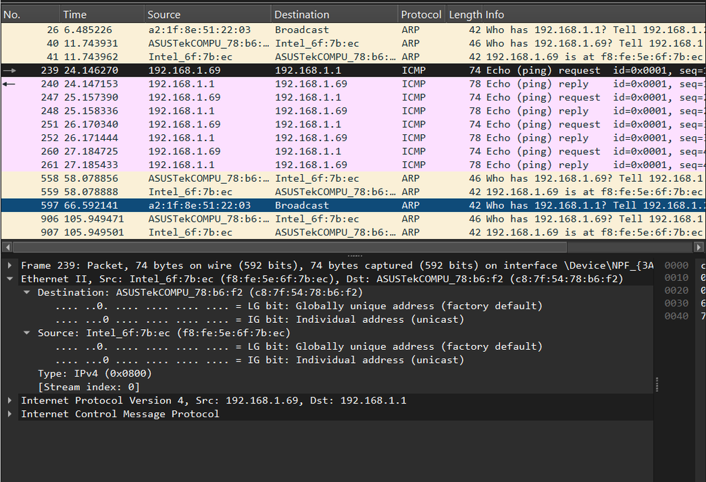

ICMP Echo request

## ICMP Echo Reply

- ICMP Echo Reply от шлюза:
  - Длина кадра: 78 bytes
  - Ethernet II (фиксируется 802.1Q VLAN в деталях)
  - Src MAC: `c8:7f:54:78:b6:f2`
  - Dst MAC: `f8:fe:5e:6f:7b:ec`

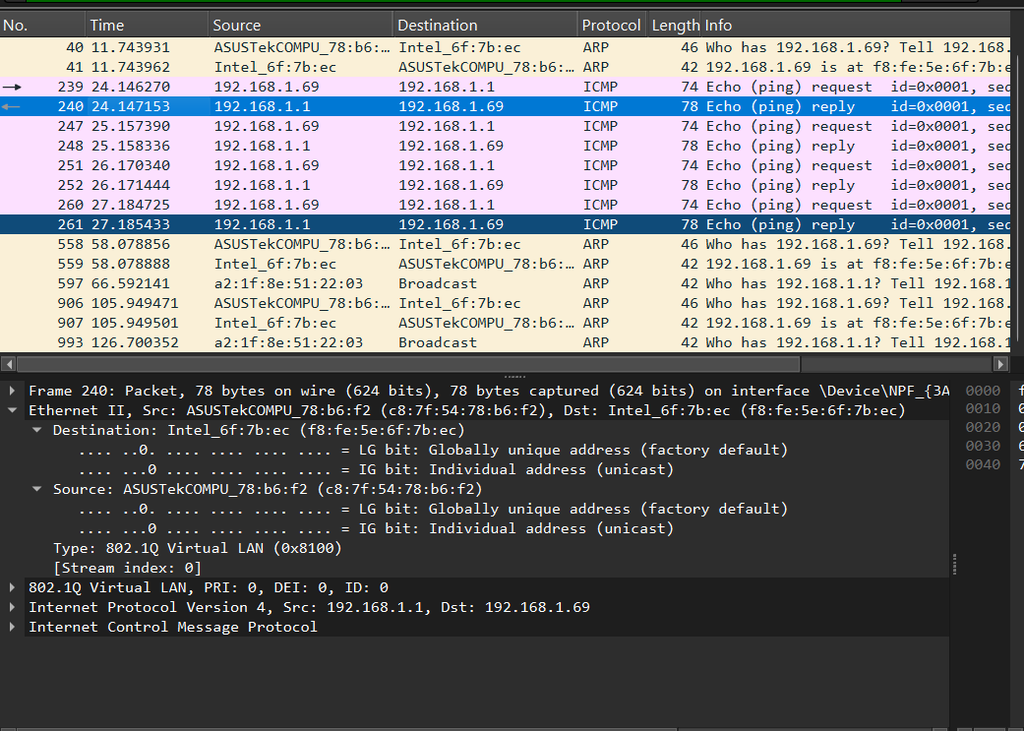

ICMP Echo reply

## ARP request

- ARP используется для сопоставления IP↔︎MAC в сегменте L2
- Рассмотрен ARP request:
  - Ethernet II + ARP (0x0806)
  - Длина кадра: 46 bytes
  - Отображается 802.1Q VLAN (0x8100)

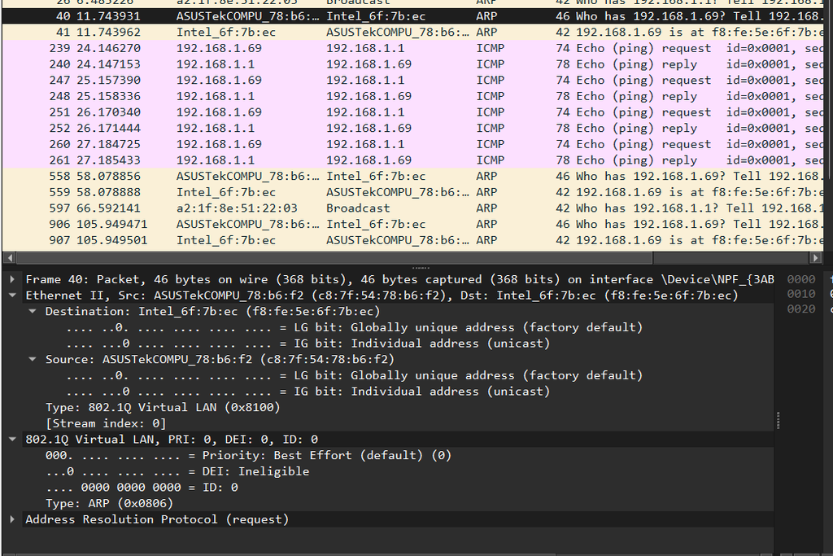

ARP request

## Ping по доменному имени и ARP reply

- Выполнен `ping www.yandex.ru`

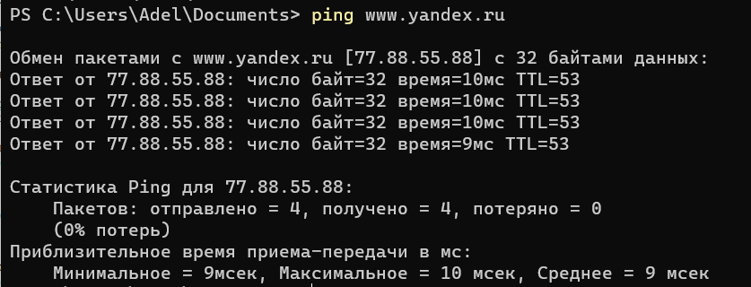

ping www.yandex.ru

## Ping по доменному имени и ARP reply

- Имя разрешено в `77.88.55.88`
- ARP reply подтверждает сопоставление IP устройства и его MAC

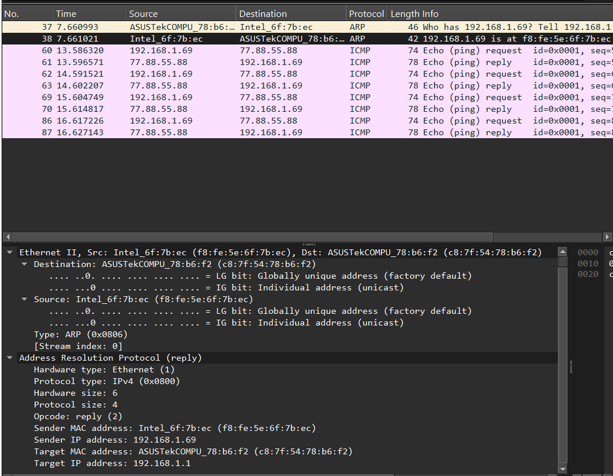

ARP reply

## ICMP к внешнему узлу: роль шлюза

- ICMP Echo Request на `77.88.55.88`
- На канальном уровне кадр адресован **MAC шлюза**, т.к. цель вне подсети

[figure not shown]

ICMP request внешний узел

## ICMP к внешнему узлу: роль шлюза

- Echo Reply приходит в локальную сеть от MAC шлюза

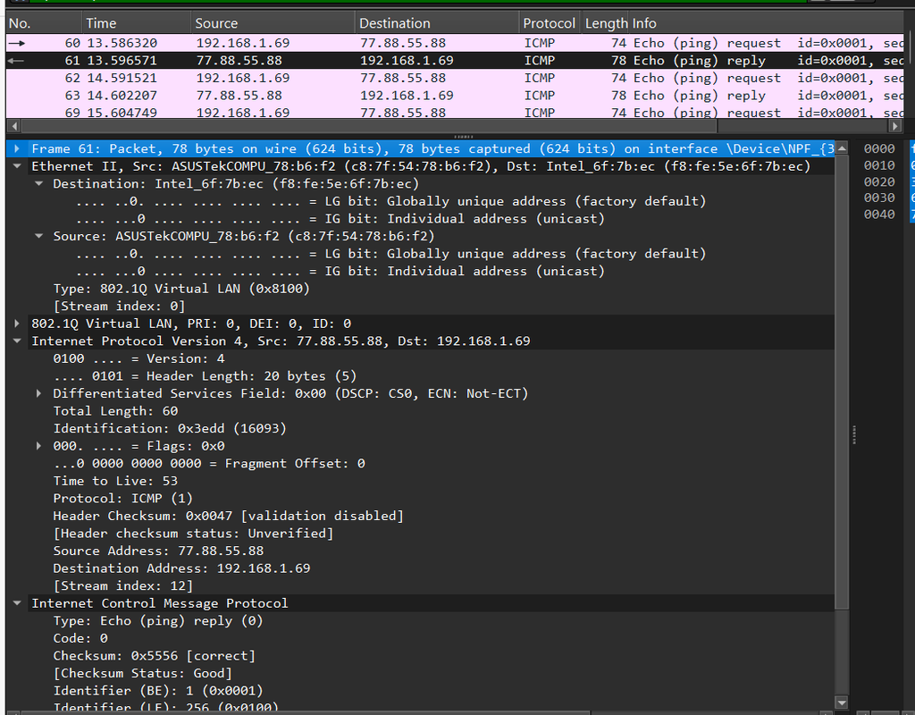

ICMP reply внешний узел

## HTTP поверх TCP: GET-запрос

Фильтр: `http` - TCP: Src Port `54457` → Dst Port `80` - Флаги: `PSH, ACK` - HTTP: `GET /hypertext/WWW/TheProject.html`

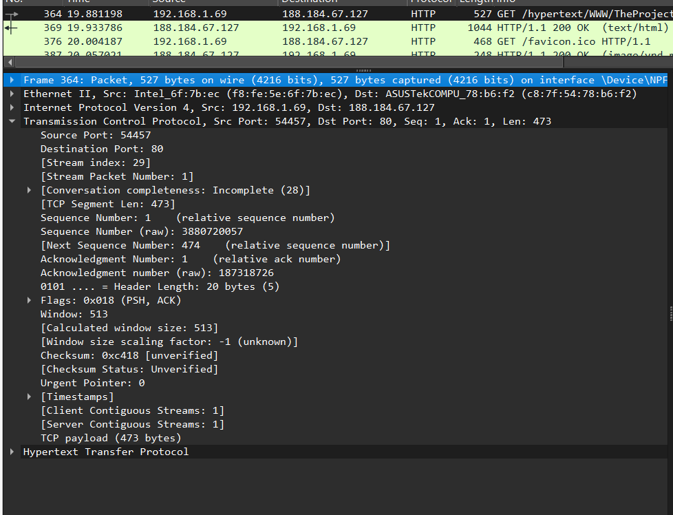

HTTP GET и TCP параметры

## HTTP ответ сервера

- HTTP/1.1 `200 OK`
- Content-Type: `text/html`
- Данные передаются несколькими сегментами (reassembly)

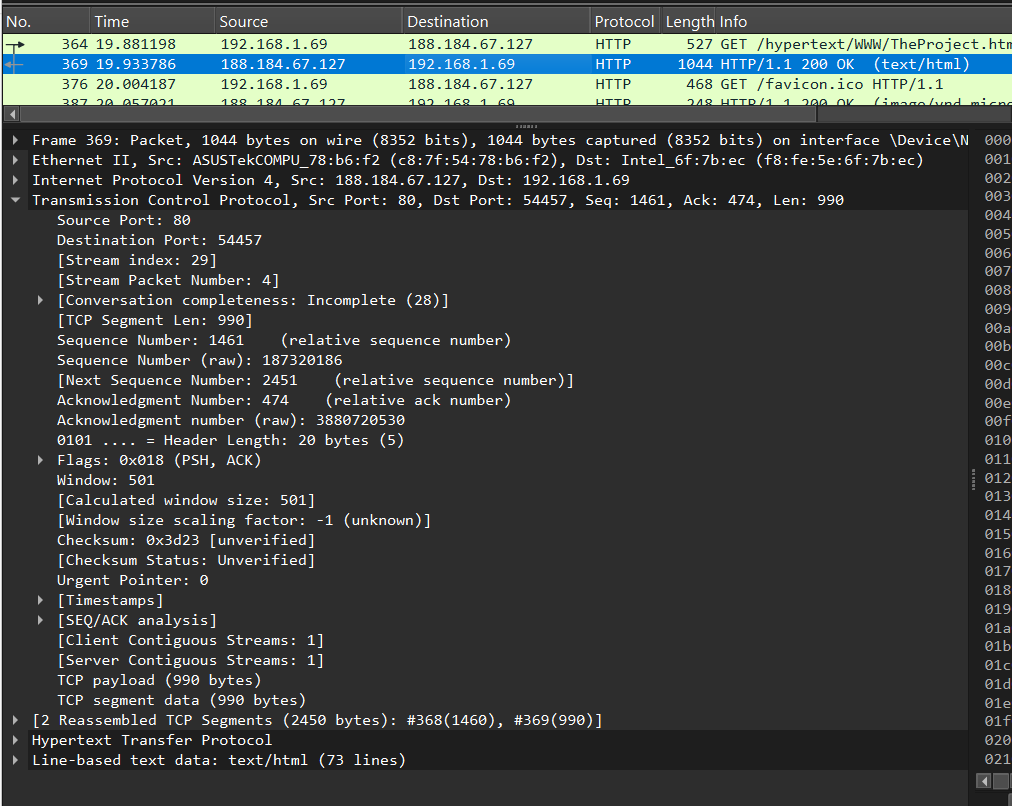

HTTP 200 OK

## DNS поверх UDP: запрос

Фильтр: `dns` - UDP: Src Port `55855` → Dst Port `53` - Src IP: `192.168.1.69` → Dst IP: `192.168.1.1` - Standard query (запрос A/HTTPS)

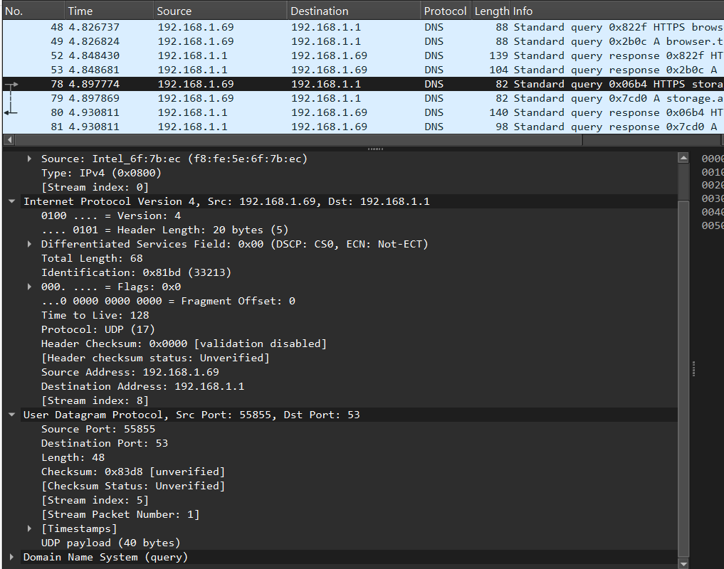

DNS query

## DNS поверх UDP: ответ

- Ответ от DNS-сервера `192.168.1.1`
- Возвращается сопоставление имени с IP
- Фиксируется TTL и служебные признаки IP

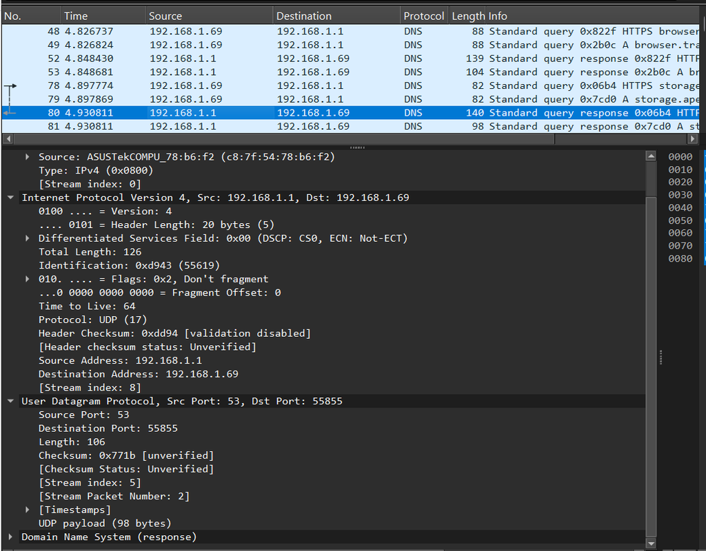

DNS response

## QUIC поверх UDP: Initial

Фильтр: `quic` - UDP: Src Port `443` → Dst Port `50215` - QUIC: Long Header, Packet Type: Initial - Используются Connection ID, передаётся криптографическая информация

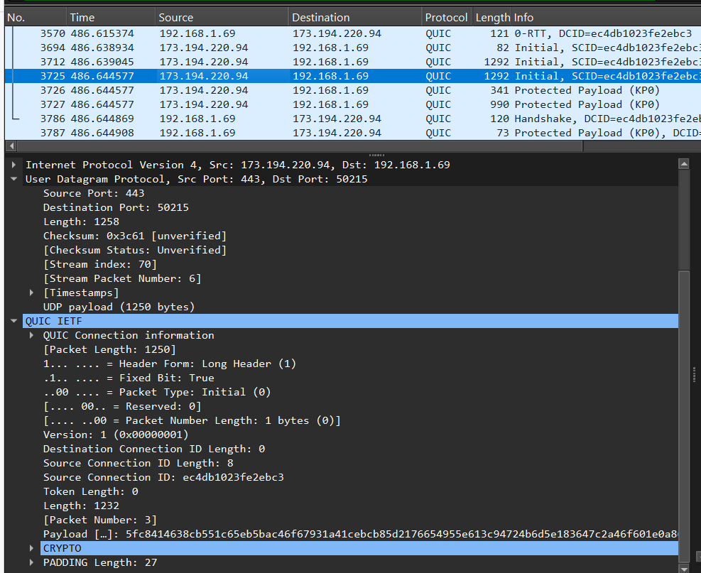

QUIC Initial

## QUIC: Handshake

- QUIC Handshake фиксируется как отдельный тип пакета
- Часть нагрузки зашифрована (без ключей расшифровка невозможна)
- QUIC объединяет транспортные механизмы и защиту соединения

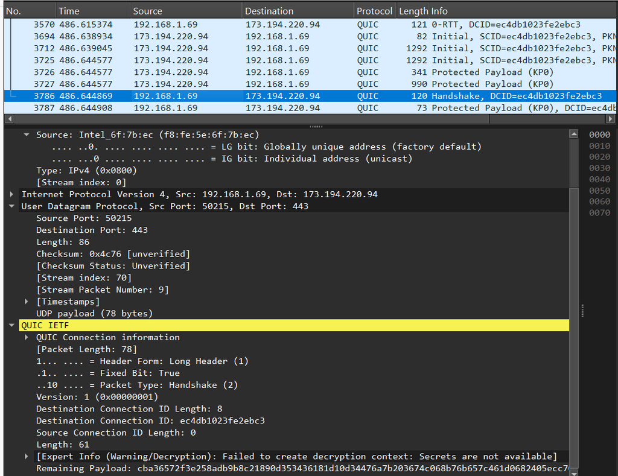

QUIC Handshake

## Установление TCP-соединения (3-way handshake)

Пример соединения к `188.184.67.127:80` - 1) **SYN** (клиент → сервер), Seq = 0 - 2) **SYN, ACK** (сервер → клиент), Ack = 1 - 3) **ACK** (клиент → сервер), Seq = 1, Ack = 1

Далее передаются данные (PSH, ACK) и соединение закрывается (FIN, ACK). RST фиксирует принудительное завершение отдельных попыток.

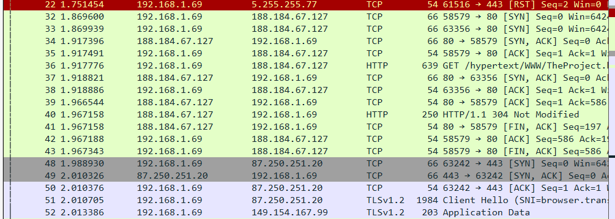

TCP handshake в списке пакетов

## График потока (Flow Graph)

- Наглядно отображены этапы `SYN → SYN,ACK → ACK`
- Видны направления обмена, рост Seq/Ack
- Отражены PSH/ACK при передаче данных и FIN/ACK при закрытии

[figure not shown]

Flow Graph TCP

# Итоговые выводы

## Заключение

- Определены параметры сетевого подключения (IP/шлюз/DNS/MAC) и подтверждена связность с шлюзом.
- Проанализированы ARP и ICMP: показаны IP↔︎MAC соответствия и отличие L2-доставки в локальной сети и при выходе во внешние сети.
- Рассмотрены HTTP (TCP), DNS (UDP), QUIC (UDP): выявлены различия в доставке данных и служебных механизмах.
- На практике подтверждён механизм TCP handshake и интерпретация Seq/Ack по графику потока Wireshark.